# Time Series Homework: Chapter 4 Lesson 2 Key

```r
pacman::p_load(
  plotly,     # plot_ly()
  tidyquant,  # tq_get()
  kableExtra  # kable(), kable_styling()
)

pacman::p_load(
  tidyverse,  # ggplot, mutate(), cleaning...
  tsibble,    # as_tsibble()
  fable,      # model(...), forecast(), tidy(), glance()...
  feasts,     # ACF(), PACF()
  ggtime,     # autoplot() for tsibbles
  rio,        # import()
  pander,     # pander() markdown tables
  patchwork   # + and / for ggplots
)
```

## Questions

### Question 1 - Random Walks: Stocks (30 points)

Modify the [code used to get the prices of McDonald’s stock](https://byuistats.github.io/timeseries/chapter_4_lesson_2.html#differencing) to download closing stock prices for a different publicly-traded company over a time period of your choice.

#### a) Create a time plot of the daily closing stock prices.

**NoteAnswer**

**plotly**

```r
# Set symbol and date range
symbol <- "TSLA"
company <- "Tesla"
date_start <- "2020-07-01"
date_end <- "2024-01-01"

# Fetch stock prices (can be used to get new data)
stock_df <- tq_get(symbol, from = date_start, to = date_end, get = "stock.prices")

# Transform data into tsibble
stock_ts <- stock_df |>
  mutate(
    dates = date,
    value = adjusted
  ) |>
  dplyr::select(dates, value) |>
  arrange(dates) |>
  mutate(diff = value - lag(value)) |>
  as_tsibble(index = dates, key = NULL)

plot_ly(stock_ts, x = ~dates, y = ~value, type = 'scatter', mode = 'lines') |>
  layout(
    xaxis = list(title = paste0("Dates (", format(ymd(date_start), "%d/%m/%Y"), " to ", format(ymd(date_end), "%d/%m/%Y"), ")" ) ),
    yaxis = list(title = "Closing Price (US$)"),
    title = paste0("Time Plot of ", symbol, " Daily Closing Price")
  )
```

[interactive chart not shown]

**ggplot**

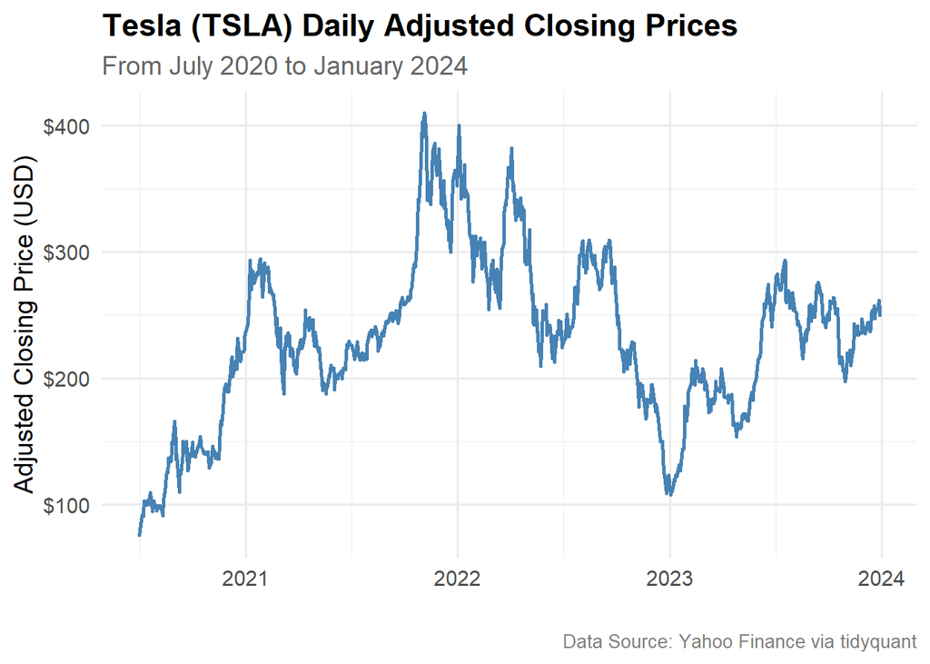

```r
ggplot(stock_ts, aes(x = dates, y = value)) +
  geom_line(color = "steelblue", linewidth = 1) +
  scale_y_continuous(
    labels = scales::label_dollar()
  ) +
  labs(
    title = "Tesla (TSLA) Daily Adjusted Closing Prices",
    subtitle = "From July 2020 to January 2024",
    x = "",
    y = "Adjusted Closing Price (USD)",
    caption = "Data Source: Yahoo Finance via tidyquant"
  ) +
  theme_minimal(base_size = 14) +
  theme(
    plot.title = element_text(face = "bold"),
    plot.subtitle = element_text(color = "gray40"),
    plot.caption = element_text(size = 10, color = "gray50")
  )
```

#### b) Create a correlogram of the daily closing stock prices. Is there evidence that daily closing stock prices follows a random walk? Please explain.

**NoteAnswer**

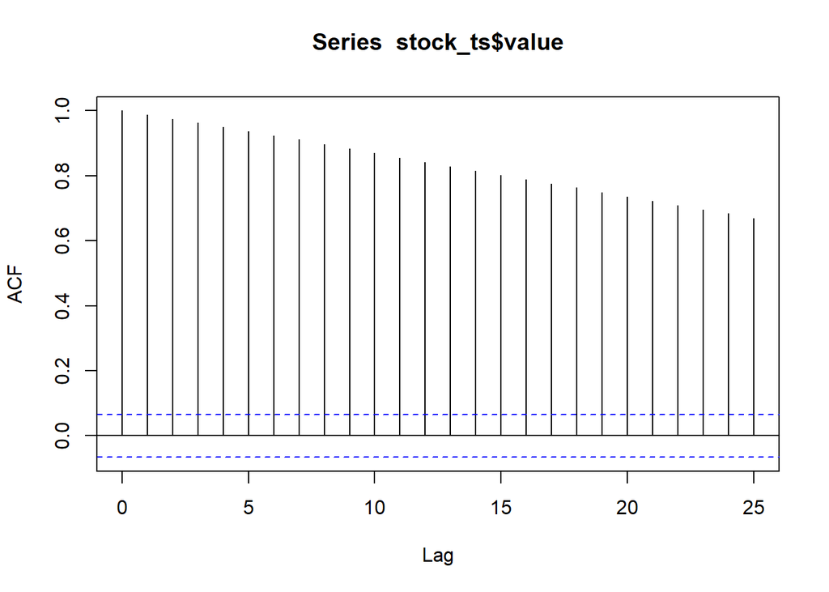

```r
acf(stock_ts$value, plot=TRUE, type = "correlation", lag.max = 25)
```

There is strong evidence suggesting a random walk. The correlogram of daily closing stock prices typically shows an autocorrelation value very close to 1 at the first lag (following the perfect correlation of 1 at lag 0), and this high correlation then decays very slowly across subsequent lags. This pattern of slow decay is typical of a non-stationary time series, which is characteristic of a random walk. In such a process, each day’s price is essentially the previous day’s price plus an unpredictable random component, meaning the series has a ‘long memory’ where past shocks are carried forward. Consequently, while the current price level is highly correlated with recent past prices, this structure implies that the changes in price (the returns) are largely random and unpredictable based on past price movements alone.

#### c) Take the first difference of your daily closing stock prices and plot the resulting time series.

**NoteAnswer**

**plotly**

```r
# Take the first difference
stock_ts_diff <- stock_ts |>
  mutate(first_diff = difference(value, 1)) |>
  filter(!is.na(first_diff))

# Plot the first-differenced series
plot_ly(stock_ts_diff, x = ~dates, y = ~first_diff, type = 'scatter', mode = 'lines') |>
  layout(
    xaxis = list(title = "Dates"),
    yaxis = list(title = "First Difference of Closing Price (US$)"),
    title = "Time Plot of First-Differenced Tesla Daily Closing Prices"
  )
```

[interactive chart not shown]

**ggplot**

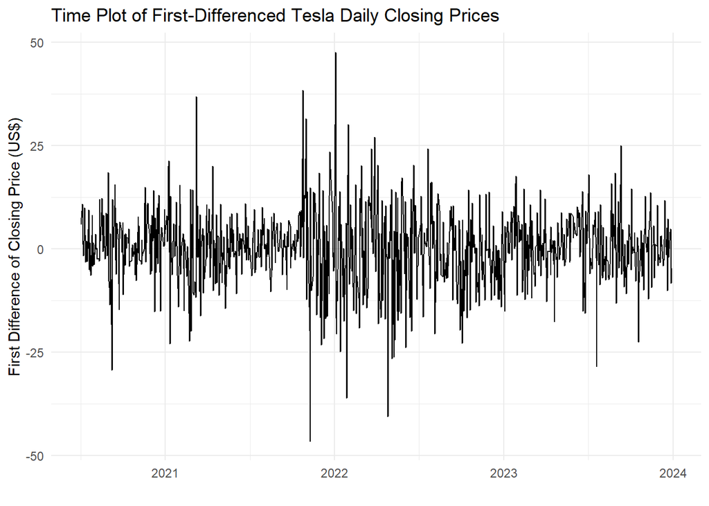

```r
autoplot(stock_ts_diff, .vars = first_diff) +
  labs(
    title = "Time Plot of First-Differenced Tesla Daily Closing Prices",
    x = "",
    y = "First Difference of Closing Price (US$)"
  ) +
  theme_minimal()
```

#### d) Create two charts, the first is a correlogram of the first-difference of daily closing stock prices. The second is a histogram of the difference in the stock prices and superimpose the corresponding normal density.

**NoteAnswer**

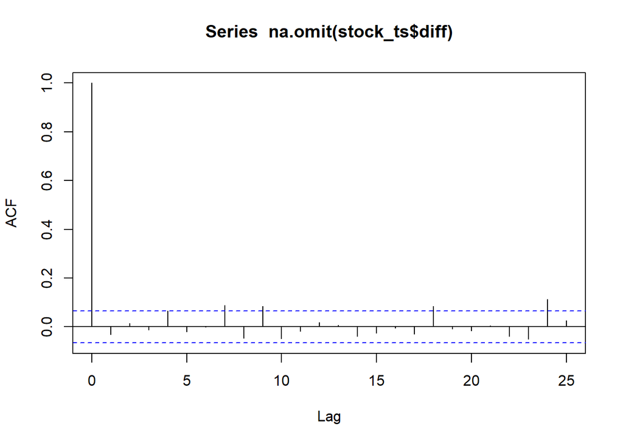

```r
# Correlogram
acf(stock_ts$diff |> na.omit(), plot=TRUE, type = "correlation", lag.max = 25)
```

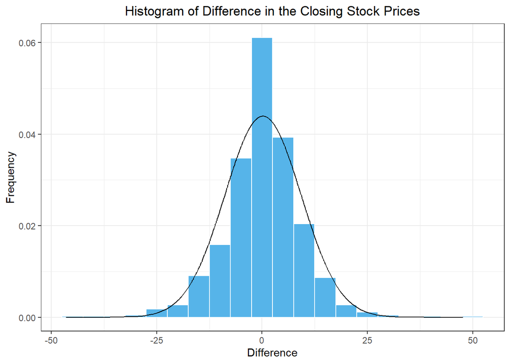

```r
# Histogram of differences in stock prices
stock_ts |>
  mutate(
    density = dnorm(diff, mean(stock_ts$diff, na.rm = TRUE), sd(stock_ts$diff, na.rm = TRUE))
  ) |>
  ggplot(aes(x = diff)) +
    geom_histogram(aes(y = after_stat(density)),
        color = "white", fill = "#56B4E9", binwidth = 5) +
    geom_line(aes(x = diff, y = density)) +
    theme_bw() +
    labs(
      x = "Difference",
      y = "Frequency",
      title = "Histogram of Difference in the Closing Stock Prices"
    ) +
    theme(
      plot.title = element_text(hjust = 0.5)
    )
```

#### e) Using your results from parts c and d, is there evidence that the first difference of daily closing stock prices follows a white noise process? Please explain.

**NoteAnswer**

This appears to follow a white noise process. We can see this with the histogram of these differences showing a normal distribution centered around zero. The ACF plot of the first differences of the daily closing stock prices also provides strong evidence that this differenced series largely follows a white noise process. This is because after the definitional spike of 1 at lag 0, almost all subsequent autocorrelation values fall within the blue dashed significance bands, indicating that they are not statistically different from zero. This shows a lack of significant correlation, which is a defining characteristic of white noise. The observation of a few lags potentially nearing or slightly exceeding significance bounds is not uncommon due to statistical error, random chance or minor deviations from a pure white noise process.

### Question 2 - Random Walks with drift and exponentially weighted slopes: Stocks (20 points)

Using the daily closing stock prices series of the previous question. Can you find evidence that there is drift in the series.

#### a) Please calculate the mean and standard deviation of the first-difference daily closing stock prices series of the previous question.

**NoteAnswer**

```r
# Calculate mean and standard deviation
diff_mean <- mean(stock_ts_diff$first_diff, na.rm = TRUE)
diff_sd <- sd(stock_ts_diff$first_diff, na.rm = TRUE)

# Display the results in a table
results <- tibble(
  Statistic = c("Mean", "Standard Deviation"),
  Value = c(diff_mean, diff_sd)
)

kable(results, caption = "Mean and Standard Deviation of First-Differenced Tesla Closing Prices") |>
  kable_styling(full_width = FALSE)
```

Mean and Standard Deviation of First-Differenced Tesla Closing Prices

| Statistic | Value |
| --- | --- |
| Mean | 0.1975432 |
| Standard Deviation | 9.0797725 |

#### b) Please evaluate the need to include a drift component in our random walk model. Provide statistical evidence justifying your conclusion.

**NoteAnswer**

```r
# Given values
n <- 880
alpha <- 0.05

# Calculate standard error
SE <- diff_sd / sqrt(n)

# Calculate critical t-value
t_critical <- qt(1 - alpha/2, df = n - 1)

# Calculate confidence interval
CI_lower <- diff_mean - t_critical * SE
CI_upper <- diff_mean + t_critical * SE

# Create a tibble to display the results
ci_results <- tibble(
  `Statistic` = c("Mean", "Lower 95% CI", "Upper 95% CI"),
  `Value` = c(diff_mean, CI_lower, CI_upper)
)

kable(ci_results, caption = "95% Confidence Interval for the Mean of First-Differenced Tesla Closing Prices") |>
  kable_styling(full_width = FALSE)
```

95% Confidence Interval for the Mean of First-Differenced Tesla Closing Prices

| Statistic | Value |
| --- | --- |
| Mean | 0.1975432 |
| Lower 95% CI | -0.4031879 |
| Upper 95% CI | 0.7982743 |

#### d) Based on the results, is there a justification to adding an exponentially weighted slope vs adding a drift parameter? Please explain.

**NoteAnswer**

The confidence interval contains zero, showing that there is no evidence to support adding in a drift parameter. Since the underlying process appears to be random, adding an exponentially weighted slope would not be advised as it is more likely to capture random shocks rather than a persistent and predictable underlying trend.

### Rubric

[output not shown]